Modulo 3 Tarea 1- Empezando con R Análisis de Regresión Marta Venegas Pardo 5/Noviembre/2021

# 1 Lectura de datos

Nos encontramos ante un dataset con 50 registros donde vienen recogidas las siguientes variables:

- Marca (cualitativa)
- Velocidad (cuantitavia continua)
- Distancia (cuantitativa continua)

| Marca | Velocidad | Distancia |
| --- | --- | --- |
| Ford | 4 | 2 |
| Jeep | 4 | 4 |
| Honda | 7 | 10 |
| KIA | 7 | 10 |
| Toyota | 8 | 14 |
| BMW | 9 | 16 |

```
## $names
## [1] "Marca"     "Velocidad" "Distancia"
##
## $class
## [1] "data.frame"
##
## $row.names
##  [1]  1  2  3  4  5  6  7  8  9 10 11 12 13 14 15 16 17 18 19 20 21 22 23 24 25
## [26] 26 27 28 29 30 31 32 33 34 35 36 37 38 39 40 41 42 43 44 45 46 47 48 49 50
```

Breve resumen de las variables a continuación:

```
##      Marca      Velocidad      Distancia
##  Dodge  : 3   Min.   : 4.0   Min.   :  2.00
##  Honda  : 3   1st Qu.:12.0   1st Qu.: 26.00
##  Jeep   : 3   Median :15.0   Median : 36.00
##  KIA    : 3   Mean   :15.4   Mean   : 42.98
##  Acura  : 2   3rd Qu.:19.0   3rd Qu.: 56.00
##  Audi   : 2   Max.   :25.0   Max.   :120.00
##  (Other):34
```

No hay valores nulos, si no tendríamos la información aqui

```
##  [1] Ford       Jeep       Honda      KIA        Toyota     BMW
##  [7] Mercedes   GM         Hyundai    Infiniti   Land Rover Lexus
## [13] Mazda      Mitsubishi Nissan     GMC        Fiat       Chrysler
## [19] Dodge      Acura      Audi       Chevrolet  Buick      Ford
## [25] Jeep       Honda      KIA        Toyota     BMW        Mercedes
## [31] GM         Hyundai    Infiniti   Land Rover Lexus      Mazda
## [37] Mitsubishi Nissan     GMC        Fiat       Chrysler   Dodge
## [43] Acura      Audi       Chevrolet  Buick      Jeep       Honda
## [49] KIA        Dodge
## 23 Levels: Acura Audi BMW Buick Chevrolet Chrysler Dodge Fiat Ford GM ... Toyota
```

De los 50 registros, encontramos 23 marcas diferentes.

## 1.1 Representaciones gráficas con ggplot2

### 1.1.1 Histograma

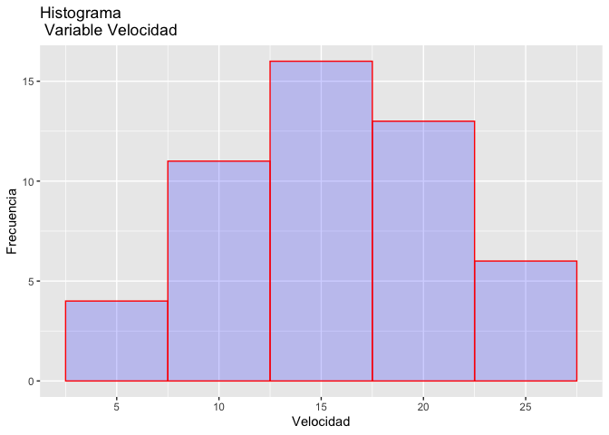

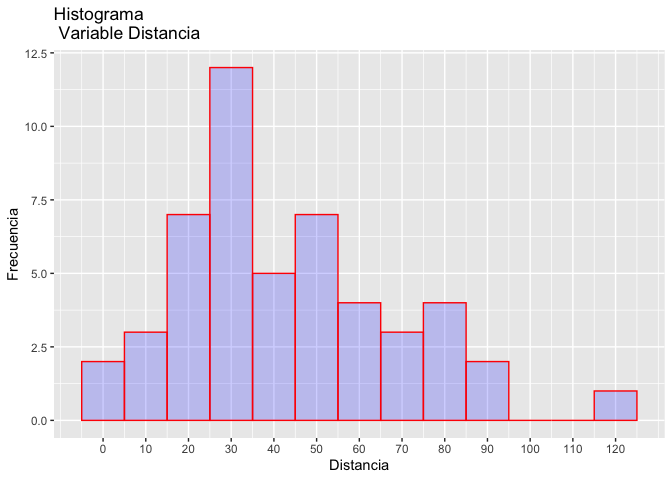

```
## [1] 1
```

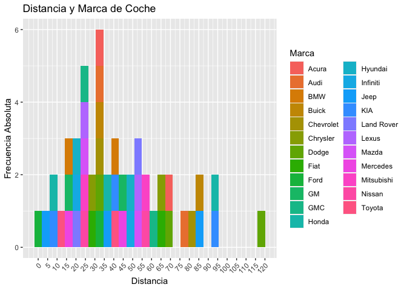

En este gráfico podemos ver la distancia que ha recorrido cada coche particular según la marca, es decir. Para la marca *Acura*, tenemos dos registros, uno que ha recorrido una distancia de 32 unidades y otro que ha recorrido 70.

### 1.1.2 Diagrama de Caja y bigote (Marca vs Velocidad)

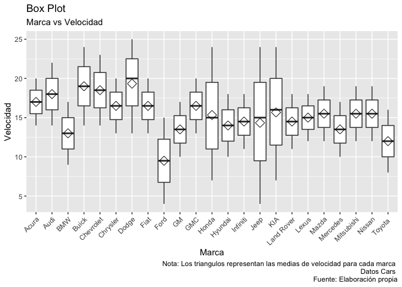

### 1.1.3 Nube de puntos Distancia vs Velocidad

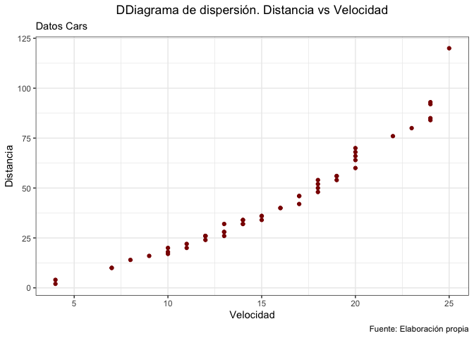

El diagrama de dispersión parece indicar una posible relación lineal entre la variable velocidad y distancia, ya que a medida que aumenta la distancia, aumenta la velocidad de conducción.

## 1.2 Gráficos de normalidad

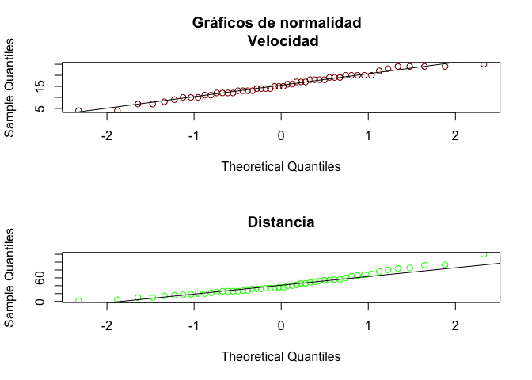

Nota importante: Esto es sólo un método gráfico, siempre debemos comprobar la normalidad con un test de hipótesis, como el test de Shapiro-Wilk

### 1.2.1 Test de normalidad

```
##
##  Shapiro-Wilk normality test
##
## data:  Cars$Velocidad
## W = 0.97765, p-value = 0.4576
```

```
##
##  Shapiro-Wilk normality test
##
## data:  Cars$Distancia
## W = 0.95144, p-value = 0.0391
```

# 2 Preprocesado de datos

```
##      Marca      Velocidad      Distancia
##  Dodge  : 3   Min.   : 4.0   Min.   :  2.00
##  Honda  : 3   1st Qu.:12.0   1st Qu.: 26.00
##  Jeep   : 3   Median :15.0   Median : 36.00
##  KIA    : 3   Mean   :15.4   Mean   : 42.98
##  Acura  : 2   3rd Qu.:19.0   3rd Qu.: 56.00
##  Audi   : 2   Max.   :25.0   Max.   :120.00
##  (Other):34
```

No existen valores NA.

La dimensión de nuestros datos es la siguiente:

- 50, 3
- 50 Registros
- 3 Variables

# 3 DataSets de Entrenamiento y Testeo

Dividimos el dataset en 70$\%$ para entrenamiento y 30$\%$ para testeo.

```
##  Longitud de datos de entrenamiento: 35
##  Longitud de datos de testeo: 15
```

Datos de entrenamiento

|  | Marca | Velocidad | Distancia |
| --- | --- | --- | --- |
| 14 | Mitsubishi | 12 | 26 |
| 16 | GMC | 13 | 26 |
| 26 | Honda | 15 | 36 |
| 28 | Toyota | 16 | 40 |
| 24 | Ford | 15 | 34 |
| 29 | BMW | 17 | 42 |

Datos de testeo

|  | Marca | Velocidad | Distancia |
| --- | --- | --- | --- |
| 4 | KIA | 7 | 10 |
| 5 | Toyota | 8 | 14 |
| 6 | BMW | 9 | 16 |
| 7 | Mercedes | 10 | 17 |
| 15 | Nissan | 12 | 26 |
| 18 | Chrysler | 13 | 28 |

# 4 Modelo de regresión lineal

Modelo lineal: Trataremos de explicar la variable distancia en función de la velocidad.

- Variable objetivo: Distancia
- Variable explicativa: Velocidad

```
##
## Call:
## lm(formula = Distancia ~ Velocidad, data = trainSet)
##
## Residuals:
##    Min     1Q Median     3Q    Max
## -8.774 -4.988 -2.059  1.083 30.940
##
## Coefficients:
##             Estimate Std. Error t value Pr(>|t|)
## (Intercept) -30.5851     4.2261  -7.237 2.67e-08 ***
## Velocidad     4.7858     0.2576  18.578  < 2e-16 ***
## ---
## Signif. codes:  0 '***' 0.001 '**' 0.01 '*' 0.05 '.' 0.1 ' ' 1
##
## Residual standard error: 8.001 on 33 degrees of freedom
## Multiple R-squared:  0.9127, Adjusted R-squared:  0.9101
## F-statistic: 345.2 on 1 and 33 DF,  p-value: < 2.2e-16
```

Conclusiones:

- Modelo: $\text{Distancia}=-30.58 + 4.7858 \cdot \text{Velocidad}$
  - Nota: El modelo general obtenido en la salida es el siguiente. $\hat y = \hat\beta_0 + \hat\beta_1 x_1$
- p-valor correspondiente al coeficiente de la velocidad: $2,2 \cdot 10^{-16} < \alpha = 0.05$, existen evidencias significativas que afirman que la velocidad afecta a la distancia, el p-valor es muy pequeño y el valor del estadístico es muy grande (*rechazo la hipótesis nula* $H_0: \beta_{\text{Velocidad}}=0$. Este contraste es equivalente a decir que no hay relación lineal entre ambas variables, por lo que la pendiente del modelo es nula).
- $R^2 = 0.9127$. Tenemos un buen ajuste, el modelo explica un 91.27 $\%$ de la variabilidad total.

## 4.1 Condiciones para la regresión lineal (assumptions), plot del modelo y estudio de los resíduos

El residuo de las estimaciones se definen de la siguiente forma: diferencia entre el valor observado y el valor esperado según el modelo.

Cuanto mayor es la suma de cuadrados de los residuos (suma de los resíduos al cuadrado) menor la precisión con la que el modelo puede predecir el valor de la variable Distancia (dependiente) a partir de la variable Velocidad (predictora).

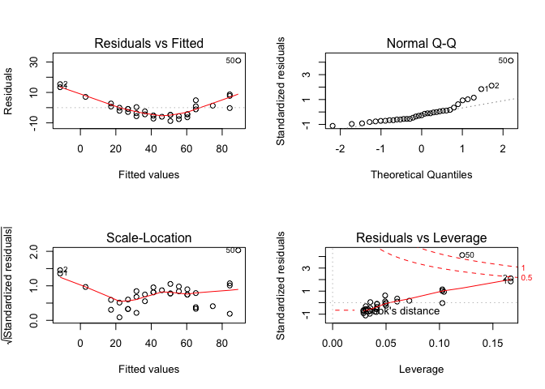

```r
par(mfrow=c(2,2))
plot(modelo1)
```

```r
par(mfrow=c(1,1))
```

Conclusiones:

**Residuals vs Fitted values** Si los puntos se distribuyen de manera aleatoria en torno al 0 (linea discontinua), diremos que la relación entre las variables es lineal (*Assumption 1: Relación de linealidad entre variables*). Para nuestro ajuste, vemos tendencia curva en los puntos y no en torno a una recta.

- **Normal Q-Q** Como hemos dicho anteriormente, para estudiar gráficamente la normalidad de los resíduos, si esta se diera, los puntos se ajustarían en torno a la recta. Los valores de los extremos suelen alejarse de la recta, indicando la no normalidad de los resíduos, es decir, violación de la hipótesis de normalidad, aunque puede que no sean puntos significativos. En nuestro caso, la observación 50 se aleja mucho, valor extremo. (*Assumption 10: Normalidad de los resíduos*)
- **Scale-Location** Estudia la igualdad de varianzas (homocedasteceidad) de los resíduos. Si la varianza fuera constante, los resíduos en el gráfico se distribuirían de forma aleatoria y entorno a la línea (que sería aproximadamente horizontal) . En caso de que no se diera homocedasteceidad, los puntos en el gráfico tendrían un patron (muy común el gráfico de embudo), indicando que la varianza no es constante. (*Assumption 3: Homoscedasticity of residuals or equal variance*)
  - A continuación vemos una imagen en la que los resíduos no se distribuyen de forma aleatoria y el gráfico tiene forma de *embudo*, indicando así que los resíduos no tienen igual varianza. Además la linea roja no es horizontal.

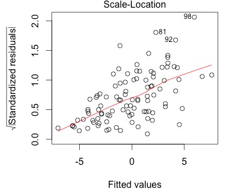

  No homocedasteceidad de los resíduos

- **Residuals vs Leverage**: Encontrar valores atípicos e influyentes (puntos leverage). Estas últimas son aquellas que, en caso de ser eliminadas, provocarían cambios en el modelo, por lo que debemos estudiar estos casos y considerar si mantenerlos en el modelo o excluirlos de éste. Son los puntos que aparecen fuera de las líneas rojas, o muy al límite Para nuestro caso encontramos tres observaciones que deberíamos estudiar: 50, 2 y 1 (al límite)

Nota: Puede que una observación influyente no sea un outlier, aunque éstos tienden a tener influencia en el modelo

### 4.1.1 *Assumption 4: No autocorrelación de los resíduos*

- Nota: Muy interesante para el estudio de series temporales, aquí carece de sentido, pero lo ilustramos a modo teórico.

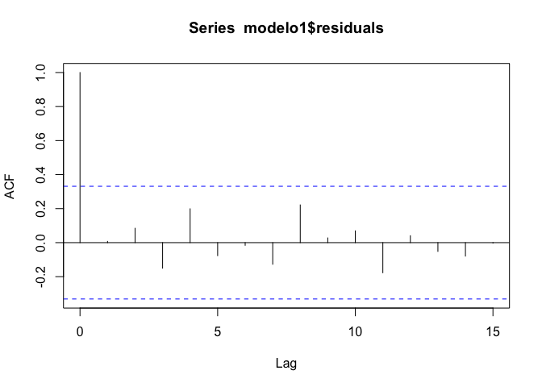

No existe patrón, la primera línea es la autocorrelación del primer resíduo con el mismo, por lo que siempre será uno. Podríamos decir que los resíduos no están muy correlados.

Nota: Volvemos a repetir que esto es a modo gráfico, no podemos asumir ninguna conclusión sin un test de hipótesis.

La imagen que mostramos a continuación es de unos resíduos con una grán correlación, donde cada resíduo depende de los anteriores y existe una tendencia decreciente:

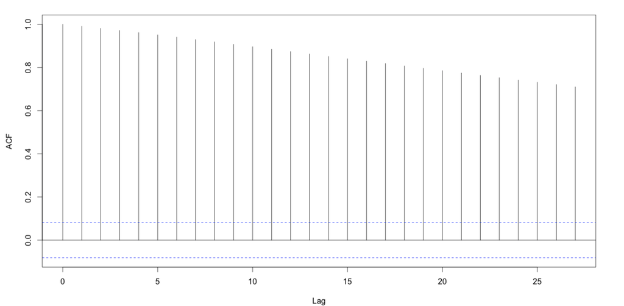

Contraste de la autocorrelación de los resíduos:

```
##
##  Approximate runs rest
##
## data:  modelo1$residuals
## Runs = 19, p-value = 0.8598
## alternative hypothesis: two.sided
```

No existen evidencias para no asumir que no existe autocorrelación entre los resíduos.

### 4.1.2 Assumption 5 La variable explicativa y los resíduos son incorrelados

```
##
##  Pearson's product-moment correlation
##
## data:  trainSet$Velocidad and modelo1$residuals
## t = 1.5112e-16, df = 33, p-value = 1
## alternative hypothesis: true correlation is not equal to 0
## 95 percent confidence interval:
##  -0.3332465  0.3332465
## sample estimates:
##         cor
## 2.63058e-17
```

No existen evidencias en contra de la hipótesis nula de la no correlación de los resíduos y la variable X (velocidad)

### 4.1.3 Assumption 9: No multicolinealidad

No es aplicable para un modelo de regresión lineal simple, para que exista multicolinealidad necesito al menos dos variables predictoras.

### 4.1.4 Comprobar las condiciones automáticamente

```
##
## Call:
## lm(formula = Distancia ~ Velocidad, data = trainSet)
##
## Coefficients:
## (Intercept)    Velocidad
##     -30.585        4.786
##
##
## ASSESSMENT OF THE LINEAR MODEL ASSUMPTIONS
## USING THE GLOBAL TEST ON 4 DEGREES-OF-FREEDOM:
## Level of Significance =  0.05
##
## Call:
##  gvlma::gvlma(x = modelo1)
##
##                     Value   p-value                   Decision
## Global Stat        90.403 0.000e+00 Assumptions NOT satisfied!
## Skewness           25.334 4.821e-07 Assumptions NOT satisfied!
## Kurtosis           38.665 5.032e-10 Assumptions NOT satisfied!
## Link Function      24.926 5.956e-07 Assumptions NOT satisfied!
## Heteroscedasticity  1.478 2.242e-01    Assumptions acceptable.
```

- Contraste: Se cumplen las condiciones vs. No se cumplen
- Conclusión, al ser un p-valor pequeño, no existen evidencias significativas para afirmar que se cumplen las condiciones para la regresión lineal.

# 5 Predicciones

Predicciones de la distancia. Intervalos de Confianza

|  | fit | lwr | upr |
| --- | --- | --- | --- |
| 4 | 2.915531 | -14.1897113 | 20.02077 |
| 5 | 7.701339 | -9.2742619 | 24.67694 |
| 6 | 12.487146 | -4.3741129 | 29.34841 |
| 7 | 17.272953 | 0.5104227 | 34.03548 |
| 15 | 26.844568 | 10.2315841 | 43.45755 |
| 18 | 31.630375 | 15.0677773 | 48.19297 |
| 21 | 36.416183 | 19.8874980 | 52.94487 |
| 23 | 36.416183 | 19.8874980 | 52.94487 |
| 27 | 45.987798 | 29.4771649 | 62.49843 |
| 34 | 55.559412 | 39.0003683 | 72.11846 |
| 35 | 55.559412 | 39.0003683 | 72.11846 |
| 39 | 65.131027 | 48.4576869 | 81.80437 |
| 42 | 65.131027 | 48.4576869 | 81.80437 |
| 45 | 79.488449 | 62.5232535 | 96.45364 |
| 47 | 84.274257 | 67.1807172 | 101.36780 |

|  | Valor Real | Predicción | Error |
| --- | --- | --- | --- |
| 4 | 10 | 2.915531 | 7.0844687 |
| 5 | 14 | 7.701339 | 6.2986613 |
| 6 | 16 | 12.487146 | 3.5128539 |
| 7 | 17 | 17.272953 | -0.2729534 |
| 15 | 26 | 26.844568 | -0.8445682 |
| 18 | 28 | 31.630375 | -3.6303755 |
| 21 | 32 | 36.416183 | -4.4161829 |
| 23 | 34 | 36.416183 | -2.4161829 |
| 27 | 40 | 45.987798 | -5.9877977 |
| 34 | 52 | 55.559412 | -3.5594124 |
| 35 | 54 | 55.559412 | -1.5594124 |
| 39 | 60 | 65.131027 | -5.1310271 |
| 42 | 68 | 65.131027 | 2.8689729 |
| 45 | 80 | 79.488449 | 0.5115508 |
| 47 | 85 | 84.274257 | 0.7257434 |

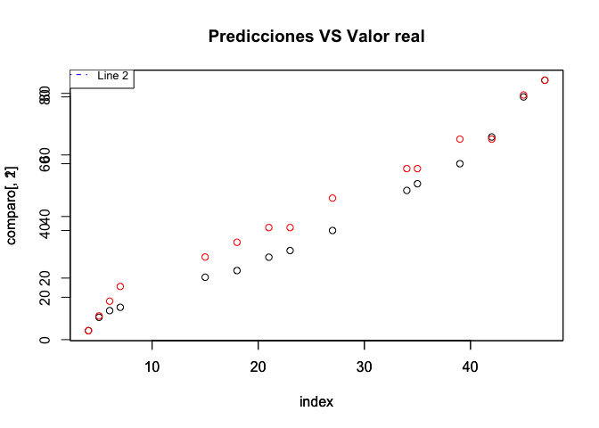